# Containment CogSci Analyses

Kevin A Smith

Jan 22, 2017

# Analysis logic

To test whether people are using simulation or containment processing, we measured reaction times across the various types of containment (size, porousness, stopperage, and complexity), the levels of that dimension, and the motion condition (Towards, No motion, or Away).

If people are relying on simulation for a given condition, then motion in the direction of the goal (Towards) should make simulation easier since those simulations should be shorter and involve fewer bounces than if the simulations are initialized in the other direction (Away), or not initialized so must travel in many different directions (No motion). If reaction time is lower in the “Towards” motion condition as compared to the other two conditions, this is used as an indication that people are in general using simulation for those types of containment trials.

We varied four dimensions of containment at three levels each (refered to as A, B, and C, though what these dimension leters stand for differs by dimension):

### Size

This dimension was used to test whether containment parsing works based on screen / DVA size, or whether it is based on the configuration of the scene. If people are trying to fill space around the ball at a constant rate then the time to parse containment should vary linearly with size. If, on the other hand, containment is based on more configural processing, or if flooding steps are relative to the local area, then we should see people be insensitive to this dimension.

These stimuli were created such that the relative configuration of objects doesn’t change, but all of the walls and goals start from small (50% dimensions for category A), to medium (75% for category B), to large (100% for category C).

If parsing works in screen / DVA space, then we should expect that reaction times should increase linearly with size. But if we see that reaction times do not change from A to C, then we can conclude that either people process containment by parsing the scene, or adaptively exploring the scene based on container size

### Porousness

This dimension was used to test whether containment processing is broken by *any* gaps in a container, or whether it is adaptive to the object that is being contained (e.g., the ball in this case).

These stimuli were created so that the geometry of the scene was the same, with the only difference ranging from the container being completely enclosed (level A), to having a gap or multiple gaps smaller than the ball (level B), to having gaps larger than the ball (level C).

We would expect at a baseline a difference between how often people use simulation from level A to level C – the containers are simple and unbroken in level A so there should be little difference between the RTs for Towards motion and either No motion or Away motion, while the container does not actually contain the ball in level C and so we should see simulation causes Towards motion to produce faster responses.

The interesting comparison here is level B, where the wall has a small gap. If containment processing is broken by any gap, then we should see a response pattern similar to that of level C, where Towards motion is faster than other motion types. On the other hand, if people account for the size of the ball, then we would expect that the small gaps should still be considered containing, and so reaction times should not differ across the motion conditions.

### Stopperage

This dimension was used to test whether containment processing uses information about motion or simply computes reachability between two points.

The stimuli were all created so that in the A level the container is sealed by a goal. At the B level, the goal is moved away from the opening so that there is enough space for the ball to get through, but to do so would be physically implausible given the direction the ball must be going to get through that gap. At the C level, the goal is moved further away so that it is very possible for the ball to escape the container even using physical motion constraints

Similar to the porousness dimension, the interesting level is B. We expect no difference in RTs across motion conditions in level A because the ball is fully contained, whereas we expect simulation to be facilitated in the Towards condition in level C because the configuration is no longer a container. However, in level B, if people take into account physically plausible motion when parsing containment, we would expect that the scene is treated as contained and there is no difference in RTs across motion conditions. Conversely, if containment processing disregards all motion information, we should see faster reaction times in the Towards condition

### Complexity

This dimension was used to test how containment and simulation interact – even in situations where the ball is fully contained will people use simulation if parsing the boundaries of the container is too difficult? Simulation can be accomplished by working with local obstacles, but parsing containment requires keeping track of the entire boundary, which can become difficult if it is made up of many different segments. Thus we want to test whether people switch to simulation when containment is difficult to see

The stimuli here were created such that in the simplest level (A) the scenes are made of very simple configurations (e.g. a box or a line separating two sides of the screen), but more internal and external structure is added in the (B) level, and more still in the (C) level.

If complexity of the scene breaks containment processing, then participants should be equally fast to respond regardless of motion information in level A, but as the scene becomes more complex, simulation should take over and reaction times should be sped in the Towards condition.

# Results

All of these results are based on the data from 100 participants.

The plot below displays the geometric mean of reaction times across all conditions and motion types. The rows represent different dimensions of containment, while the columns represent the levels that vary along those dimensions. Bars represent 95% confidence intervals bootstrapped with 500 samples

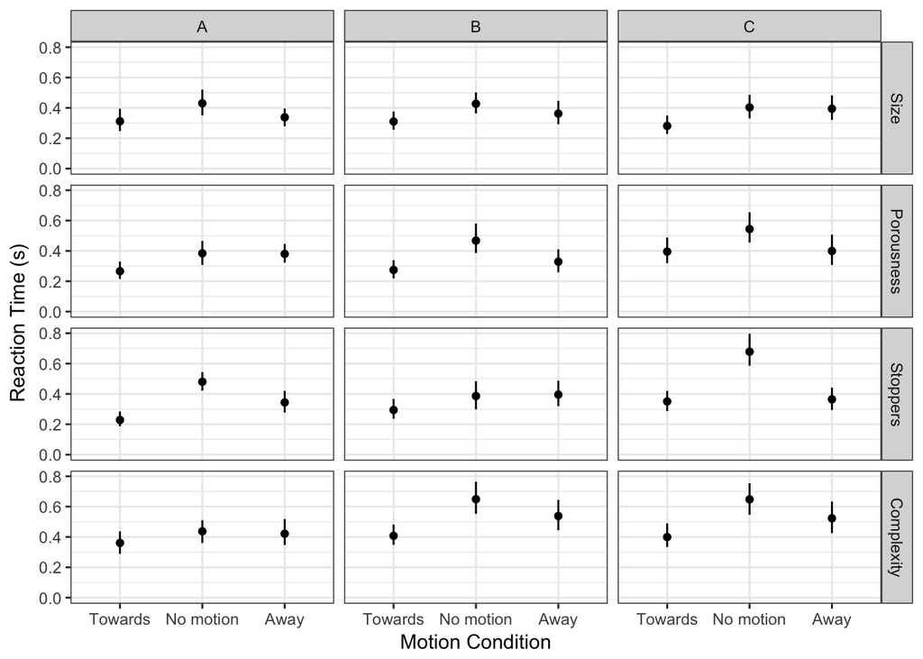

All analyses of reaction time were performed using log-RT (Whelan, 2008) but transformed into reaction times for display and reporting.

We first test for gross differences across the trial types and motion conditions. This was accomplished with a mixed-effects model using random effects for participants, trials, and the trial by motion condition interaction (to control for any differences in how the motion information might affect simulation in a particular trial).

```
## Analysis of Variance Table of type I  with  Satterthwaite
## approximation for degrees of freedom
##                                                  Sum Sq Mean Sq NumDF
## ContainmentType                                    14.2     4.7     3
## ContainmentLevel                                    6.4     3.2     2
## MotionDirection                                    67.5    33.7     2
## ContainmentType:ContainmentLevel                    4.6     0.8     6
## ContainmentType:MotionDirection                     3.6     0.6     6
## ContainmentLevel:MotionDirection                    1.3     0.3     4
## ContainmentType:ContainmentLevel:MotionDirection    9.5     0.8    12
##                                                  DenDF F.value  Pr(>F)
## ContainmentType                                     58     8.6 7.8e-05 ***
## ContainmentLevel                                    58     5.9  0.0046 **
## MotionDirection                                   2152    61.8 < 2e-16 ***
## ContainmentType:ContainmentLevel                    58     1.4  0.2252
## ContainmentType:MotionDirection                   2157     1.1  0.3564
## ContainmentLevel:MotionDirection                  2152     0.6  0.6645
## ContainmentType:ContainmentLevel:MotionDirection  2164     1.4  0.1380
## ---
## Signif. codes:  0 '***' 0.001 '**' 0.01 '*' 0.05 '.' 0.1 ' ' 1
```

Note: all numbers are given in seconds

The most important factor seems to be the motion condition, with Towards (0.321 (95% CI: [0.288, 0.357])) being faster than Away (0.394 (95% CI: [0.354, 0.439])), which in turn is faster than No Motion (0.487 (95% CI: [0.437, 0.543])) over all trial types.

The type of containment makes a difference as well, with the complex trials (0.481 (95% CI: [0.424, 0.546])) being slower than the size trials (0.359 (95% CI: [0.316, 0.407])), the porous trials (0.373 (95% CI: [0.329, 0.423])), and the stopper trials (0.377 (95% CI: [0.333, 0.428]))

Finally, the level of containment made a difference in reaction times, with the simplest / most contained trials being the fastest (0.359 (95% CI: [0.319, 0.404])), followed by the intermediate trials (0.393 (95% CI: [0.349, 0.443])), followed by the most complex / least contained (0.436 (95% CI: [0.387, 0.49]))

## Post-hoc test for simulation across conditions

Given that the motion direction has a very strong effect but does not interact with anything else, it seems as if simulation is used across all containment types and trials.

This post-hoc analysis is done to check for a “facilitation effect” of motion towards the goal: proportionally how much faster do participants respond when they see motion towards the goal as compared to either no motion or motion away? (The numbers below are calculated as $RT_{fwd}$ / $RT_{other}$)

If this number is less than 1, then the time it takes to make predictions with forward motion is less than otherwise, which suggests people are using simulation to solve these trials.

As can be seen in the table below, *every* condition shows a numerical simulation facilitation effect, and most of those cells also have 95% CIs that do not include 1 as well (Note: I need to double check the post-hoc corrections that the R package that calculated these is using, so they might grow wider). This indicates that simulation is being used across the board, no matter how simple the container is.

|  | A | B | C |
| --- | --- | --- | --- |
| Size | 0.764 [0.593, 0.983] | 0.82 [0.635, 1.06] | 0.716 [0.556, 0.921] |
| Porousness | 0.714 [0.554, 0.92] | 0.716 [0.556, 0.922] | 0.869 [0.676, 1.12] |
| Stoppers | 0.592 [0.46, 0.761] | 0.704 [0.548, 0.904] | 0.681 [0.529, 0.877] |
| Complexity | 0.845 [0.655, 1.09] | 0.7 [0.543, 0.903] | 0.713 [0.554, 0.917] |

## Containment dimension analyses

Below are the pre-planned contrasts to check for the different sorts of containment processing. This is not as important in light of the simulation findings, and might not be reported in the paper

### Size

The average time to respond to the smallest trials is 0.342s (95% CI: [0.285, 0.411]), versus 0.335s in the largest trials (95% CI: [0.279, 0.402]). Linear contrasts suggest that the reaction time in the largest trials should only take 0.979 times as long as the smallest trials (95% CI = [0.779, 1.231]).

### Porousness

The relative slowdown going from Towards motion to the average of No motion and Away along each level of porousness are:

- A (fully contained): 1.401 times slower (95% CI = [1.087, 1.805])
- B (partially open): 1.397 times slower (95% CI = [1.085, 1.797])
- C (fully open): 1.151 times slower (95% CI = [0.895, 1.48])

Pairwise tests for differences between these conditions are not statistically significant:

```
##  AltMD_pairwise ContainmentLevel_pairwise estimate    SE  df t.ratio
##  Fwd - Other    a - b                     -0.00325 0.181 126  -0.018
##  Fwd - Other    a - c                     -0.19693 0.181 126  -1.086
##  Fwd - Other    b - c                     -0.19367 0.180 124  -1.076
##  p.value
##   0.9857
##   0.2798
##   0.2842
```

### Stopperage

The relative slowdown going from Towards motion to the average of No motion and Away along each level of stopperage are:

- A (fully contained): 1.69 times slower (95% CI = [1.314, 2.173])
- B (reachable but unlikely): 1.42 times slower (95% CI = [1.106, 1.824])
- C (fully open): 1.468 times slower (95% CI = [1.14, 1.89])

Pairwise tests for differences between these conditions are not statistically significant:

```
##  AltMD_pairwise ContainmentLevel_pairwise estimate    SE  df t.ratio
##  Fwd - Other    a - b                      -0.1737 0.179 122  -0.969
##  Fwd - Other    a - c                      -0.1405 0.181 124  -0.777
##  Fwd - Other    b - c                       0.0332 0.180 123   0.185
##  p.value
##   0.3343
##   0.4388
##   0.8537
```

### Complexity

The relative slowdown going from Towards motion to the average of No motion and Away along each level of complexity are:

- A (simple): 1.184 times slower (95% CI = [0.918, 1.527])
- B (slightly complex): 1.428 times slower (95% CI = [1.107, 1.842])
- C (very complex): 1.403 times slower (95% CI = [1.09, 1.805])

The critical test here is whether the use of simulation increases in the most complex trials vs. the simplest ones – or a contrast between the advantage for Towards vs Others in level A vs C. However, given that simulation is occurring and the test is not statistically signifiant, this doesn’t tell us much about what complexity is changing in people’s mental models.

```
##  AltMD_trt.vs.ctrl ContainmentLevel_pairwise estimate    SE  df t.ratio
##  Other - Fwd       a - c                        -0.17 0.182 127  -0.932
##  p.value
##   0.3531
```

## Accuracy on contained trials

People did not perform perfectly even on the fully contained trials. This varied across trial types and motion directions. This isn’t a point that we necessarily need to put weight on in the paper, but should report it

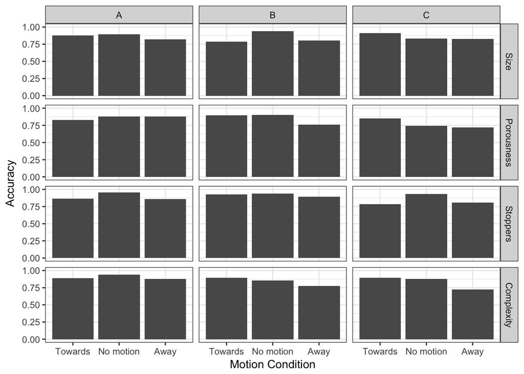

Model testing suggests that the same things that affect reaction time also seem to affect accuracy:

```
## Analysis of Deviance Table
##
## Model: binomial, link: logit
##
## Response: WasCorrect
##
## Terms added sequentially (first to last)
##
##
##                                                  Df Deviance Resid. Df
## NULL                                                              2337
## ContainmentType                                   3     7.32      2334
## ContainmentLevel                                  2    10.30      2332
## MotionDirection                                   2    20.01      2330
## ContainmentType:ContainmentLevel                  6     7.65      2324
## ContainmentType:MotionDirection                   6     7.87      2318
## ContainmentLevel:MotionDirection                  4     4.90      2314
## ContainmentType:ContainmentLevel:MotionDirection 12    14.97      2302
##                                                  Resid. Dev Pr(>Chi)
## NULL                                                   1921
## ContainmentType                                        1914   0.0623 .
## ContainmentLevel                                       1904   0.0058 **
## MotionDirection                                        1884  4.5e-05 ***
## ContainmentType:ContainmentLevel                       1876   0.2647
## ContainmentType:MotionDirection                        1868   0.2481
## ContainmentLevel:MotionDirection                       1863   0.2973
## ContainmentType:ContainmentLevel:MotionDirection       1848   0.2428
## ---
## Signif. codes:  0 '***' 0.001 '**' 0.01 '*' 0.05 '.' 0.1 ' ' 1
```

Now, people are clearly not getting *every* contained trial correct, which in some cases can probably be considered misclicks or other errors in judgment (except possibly in the Porousness and Stopperage trials). However, these trials are much easier than non-contained trials (average accuracy for contained = 0.857 vs non-contained = 0.588). And analyzing RTs for containment trials only in the cases where participants indicated the correct goal does not lead to qualitatively different results. Another explanation: people spend more time deliberating on the no motion and reverse trials

| MotionDirection | Acc |
| --- | --- |
| Fwd | 0.867 |
| None | 0.890 |
| Rev | 0.813 |

```
##  contrast   estimate    SE df z.ratio p.value
##  Fwd - None   -0.297 0.169 NA   -1.76  0.1833
##  Fwd - Rev     0.411 0.145 NA    2.83  0.0129
##  None - Rev    0.707 0.160 NA    4.43  <.0001
##
## Results are averaged over the levels of: ContainmentType, ContainmentLevel
## Results are given on the log odds ratio (not the response) scale.
## P value adjustment: tukey method for comparing a family of 3 estimates
```

# Non-contained trials

To double check, we test whether there is any differentiation in reaction time for the non-contained trials between when there is motion and when there is not. If motion doesn’t change reaction time *even when we know people are not using containment reasoning* then we won’t be able to tell anything about the contained trials when simulation is ambiguous

The regular trials with motion had shorter reaction times on average than the same trials without motion (geometric mean rt of 0.395s for motion, 0.462s for no motion, t(95)=-8.62, p=1.45e-13). This reaction time difference existed even with no reliable difference in accuracy across matched trials (mean accuracy of motion trials: 0.595, mean accuracy of no motion trials 0.575, t(95)=1.1, p=0.273).

Plots of geometric mean of RT and accuracy across trials (probably not to be used):

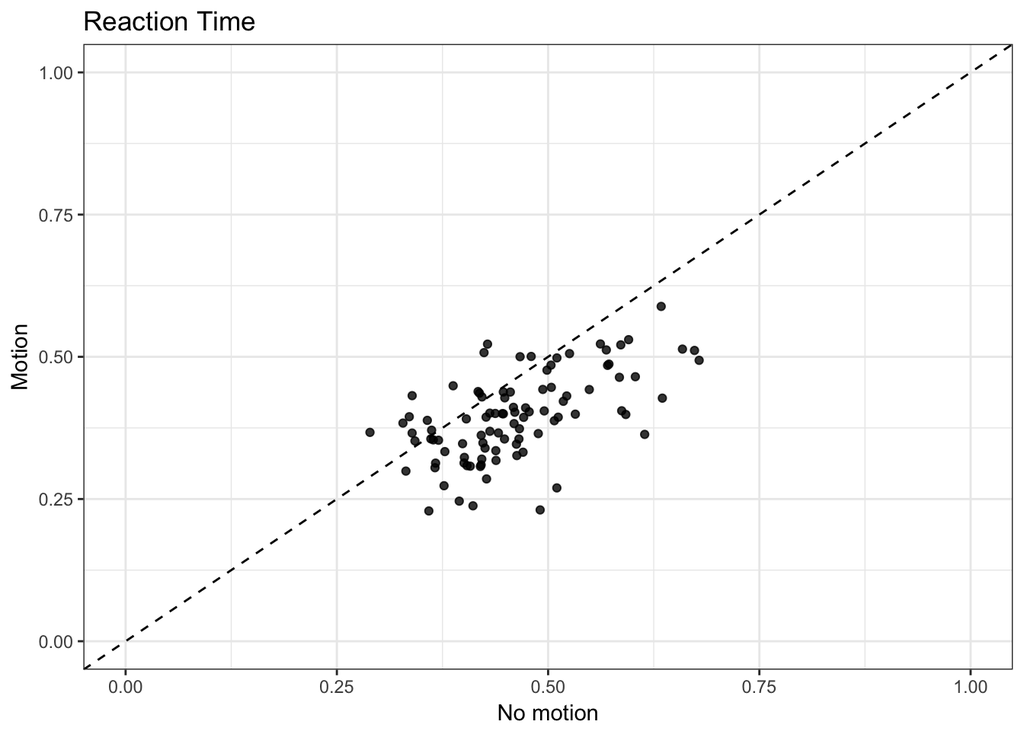

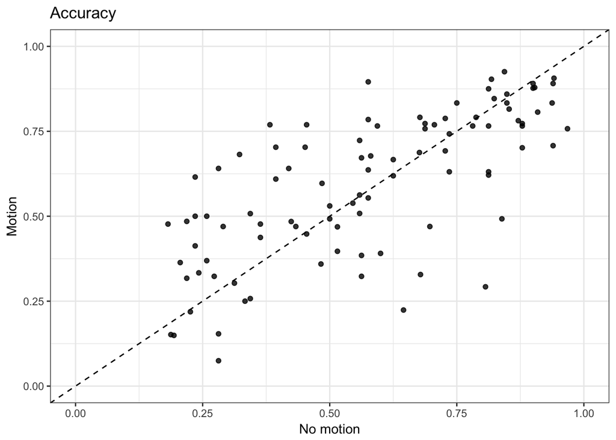